# From Alternative Data to Investment Alpha: A Textual Analysis Case Study

Witold Kozlowski

January 11, 2022

This is a case study in verifying whether an alternative data set can generate statistically significant alpha in publicly traded stocks. Specifically, we use the publicly available Consumer Financial Protection Bureau’s (CFPB) [Complaints Database](https://www.consumerfinance.gov/data-research/consumer-complaints/). We tie the data to 25 publicly traded US consumer facing financial institutions. We extract features from the data and derive variables using textual analysis of the consumer complaint narratives. The derived variable is cosine similarity of the consumer complaint narratives as they change year on year. The main idea is that if the complaints a company receives change year on year, this means something. In this case, it turns out that companies with the largest change (i.e. changers) in their complaints similarity outperform non-changers. We rank these variables by quintile and run these segments against the Fama-French factor model. While the charts for the different quintile portfolios are suggestive, their alphas are unfortunately not statistically significant. The code for this case study will be made available on Github at `witolot/consumer_complaints`.

## 1. Data Sourcing

We use the Consumer Financial Protection Bureau’s (CFPB) [Complaints Database](https://www.consumerfinance.gov/data-research/consumer-complaints/). These are complaints made against financial products of particular companies (e.g. credit scoring, credit cards, loans).

```r
# Load R libraries
library(tidyverse)
library(tidyquant)
library(lubridate)
library(stringr)
library(quanteda)
library(quanteda.textstats)

# Load data downloaded from from https://files.consumerfinance.gov/ccdb/complaints.csv.zip
df <- read_csv("data/complaints.csv")
```

## 2. Feature Selection

```r
# Visually inspect a few examples of the `Consumer complaint narrative`
df %>% select(`Consumer complaint narrative`) %>% na.omit()
```

```
#> # A tibble: 841,229 × 1
#>    `Consumer complaint narrative`
#>    <chr>
#>  1 "I contacted Ally on Friday XX/XX/XXXX after falling behind on payments due …
#>  2 "I was contacted about student loan consolidation. I agreed to consolidate m…
#>  3 "Hello This complaint is against the three credit reporting companies. XXXX,…
#>  4 "I am a victim of Identity Theft & currently have an Experian account that I…
#>  5 "Two accounts are still on my credit history after contacting the credit bur…
#>  6 "Receiving daily telephone call ( s ) from XXXX XXXX XXXX identifying themse…
#>  7 "I have a bank of America small business credit card that I had requested to…
#>  8 "I opened a citi double cash card the beginning of XXXX and still have not r…
#>  9 "Although I am checking for and addressing missing and or deficient aspects …
#> 10 "My husband left me and our XXXX children, all under the age of XXXX, in XXX…
#> # … with 841,219 more rows
```

Since not all companies which receive complaints are publicly traded, for the purpose of this exercise we’ll just peel the top 25 from the top and ticker tie them later in the workflow.

```r
# Check complaint numbers by company
df %>%
    filter(`Date received` >= as.Date("2015-01-01")) %>%
    group_by(Company) %>%
    tally(sort=TRUE)
```

```
#> # A tibble: 6,072 × 2
#>    Company                                     n
#>    <chr>                                   <int>
#>  1 EQUIFAX, INC.                          357268
#>  2 TRANSUNION INTERMEDIATE HOLDINGS, INC. 265112
#>  3 Experian Information Solutions Inc.    241806
#>  4 BANK OF AMERICA, NATIONAL ASSOCIATION   64923
#>  5 WELLS FARGO & COMPANY                   62155
#>  6 JPMORGAN CHASE & CO.                    61998
#>  7 CITIBANK, N.A.                          54236
#>  8 CAPITAL ONE FINANCIAL CORPORATION       51126
#>  9 Navient Solutions, LLC.                 30298
#> 10 SYNCHRONY FINANCIAL                     29216
#> # … with 6,062 more rows
```

```r
# Create list from top 25
bank_list <- c(
                "EQUIFAX, INC.", # NYSE: EFX
                "TRANSUNION INTERMEDIATE HOLDINGS, INC.", # TRU
                "Experian Information Solutions Inc.", # EXPGY
                "BANK OF AMERICA, NATIONAL ASSOCIATION", # NYSE: BAC
                "WELLS FARGO & COMPANY", # NYSE: WFC
                "JPMORGAN CHASE & CO.", # NYSE: JPM
                "CITIBANK, N.A.", # NYSE: C
                "CAPITAL ONE FINANCIAL CORPORATION", # NYSE: COF
                "Navient Solutions, LLC.", # NASDAQ: NAVI
                "SYNCHRONY FINANCIAL", # NYSE: SYF
                "U.S. BANCORP", # NYSE: USB
                "AMERICAN EXPRESS COMPANY", # AXP
                "PORTFOLIO RECOVERY ASSOCIATES INC", # PRAA
                "Ocwen Financial Corporation", # NYSE: OCN
                "NATIONSTAR MORTGAGE", # NSM
                "DISCOVER BANK", # DFS
                "Alliance Data Card Services", # ADS
                "PNC Bank N.A.", # NYSE: PNC
                "ENCORE CAPITAL GROUP INC.", # ECPG
                "TD BANK US HOLDING COMPANY", # NYSE: TD
                "Paypal Holdings, Inc", # PYPL
                "AES/PHEAA", # AES
                "Santander Consumer USA Holdings Inc.", # SC
                "ALLY FINANCIAL INC.", #ALLY
                "TRANSWORLD SYSTEMS INC" # TSI
                #"Ditech Financial LLC", # delisted, bankrupt in 2021
                )

# Subset df by bank list
df <- df %>% filter(Company %in% bank_list)
```

## 3. Textual Analysis

```r
# Aggregate complaint text by yearmon
df2 <- df %>%
    filter(`Date received`>=as.Date("2015-01-01")) %>%
    select(`Date received`,Company,`Consumer complaint narrative`,Product,`Sub-product`,Issue,`Sub-issue`,`Complaint ID`) %>%
    na.omit() %>%
    mutate(year=year(`Date received`)) %>%
    group_by(Company,year) %>%
    summarize(complaint = str_c(`Consumer complaint narrative`, collapse = ". "))

# View output
df2
```

```
#> # A tibble: 174 × 3
#> # Groups:   Company [25]
#>    Company  year complaint
#>    <chr>   <dbl> <chr>
#>  1 ADS      2016 "XX/XX/2015 I filed a XXXX complaint against XXXX XXXX ( now t…
#>  2 ADS      2017 "the told me to sign a piece of paper, that i did not read, be…
#>  3 ADS      2018 "Debt was paid in XX/XX/2018. Please find copy of check tho th…
#>  4 ADS      2019 "I was XXXX XXXX and while in this state my granddaughter ( my…
#>  5 ADS      2020 "I have disputed this account and have reached out to the comp…
#>  6 ADS      2021 "In XX/XX/XXXX I applied for an XXXX / XXXX XXXX XXXX and was …
#>  7 AES      2015 "I am still in my training to become an XXXX. I have completed…
#>  8 AES      2016 "I noticed that there are at least XXXX school loans on my cre…
#>  9 AES      2017 "At the beginning of XXXX, 2017, I emailed fedloan requesting …
#> 10 AES      2018 "Hello, I've worked with XXXX XXXX XXXX for my student loans. …
#> # … with 164 more rows
```

We use the `quanteda` package to run the textual analysis:

```r
# Convert df to corpus
corp_complaints <- corpus(df2, text_field = "complaint")

# Rename doc names in corpus
docid <- paste(df2$Company,df2$year, sep = " - ")
docnames(corp_complaints) <- docid

# Make tokens
toks_complaints <- tokens(corp_complaints, remove_punct = TRUE)

# Remove stop words
toks_complaints <- tokens_select(toks_complaints, pattern = stopwords("en"), selection = "remove")

# Convert to DFM format
dfmat_complaints <- dfm(toks_complaints)

# Stem words
dfmat_complaints <- dfm_wordstem(dfmat_complaints)
```

Just for demonstration purposes, after all this wrangling we can run a word cloud visualisation. In this case we’re comparing across companies for 2021.

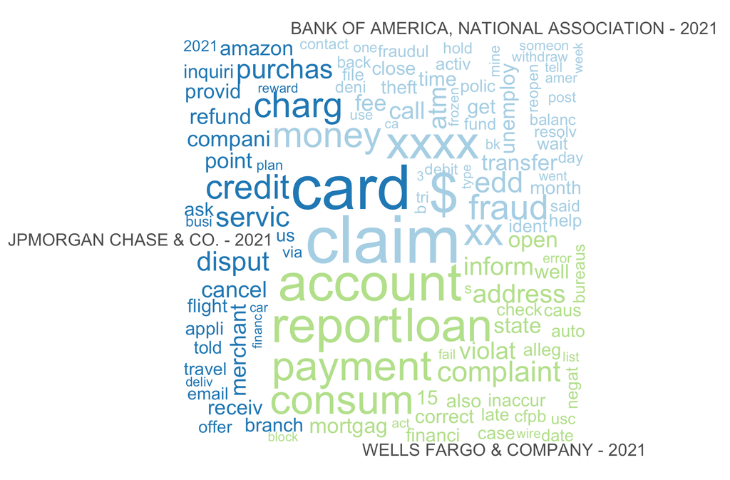

```r
knitr::include_graphics("images/wordcloud_cs.png")
```

And here’s a word cloud across time for the same company, Wells Fargo.

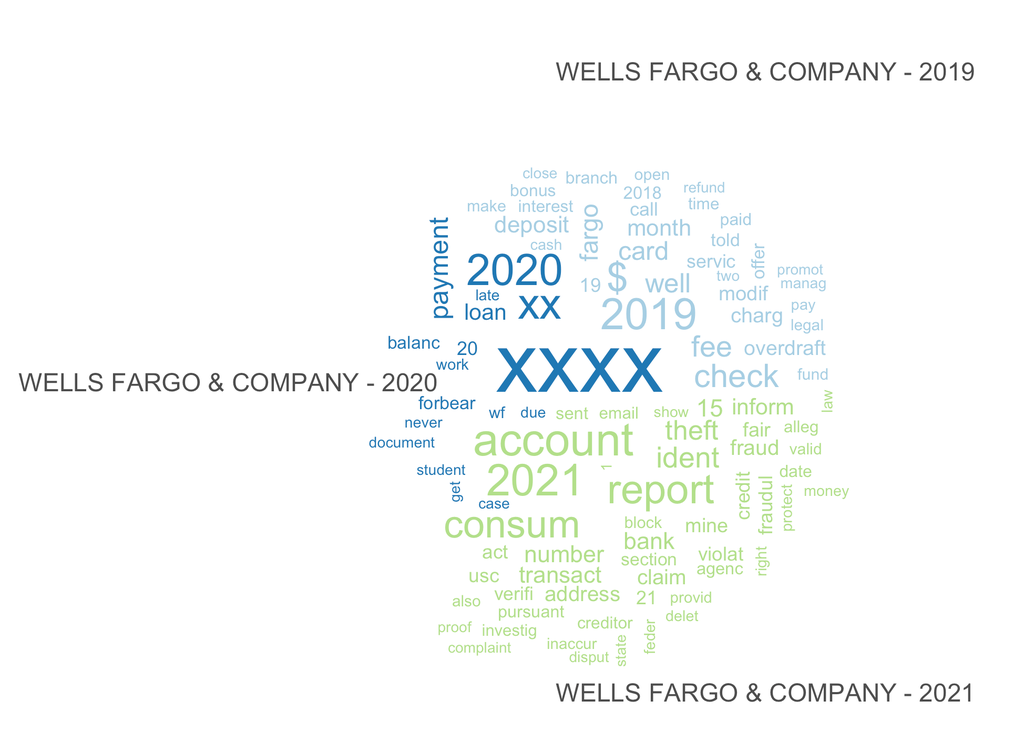

```r
knitr::include_graphics("images/wordcloud_ts.png")
```

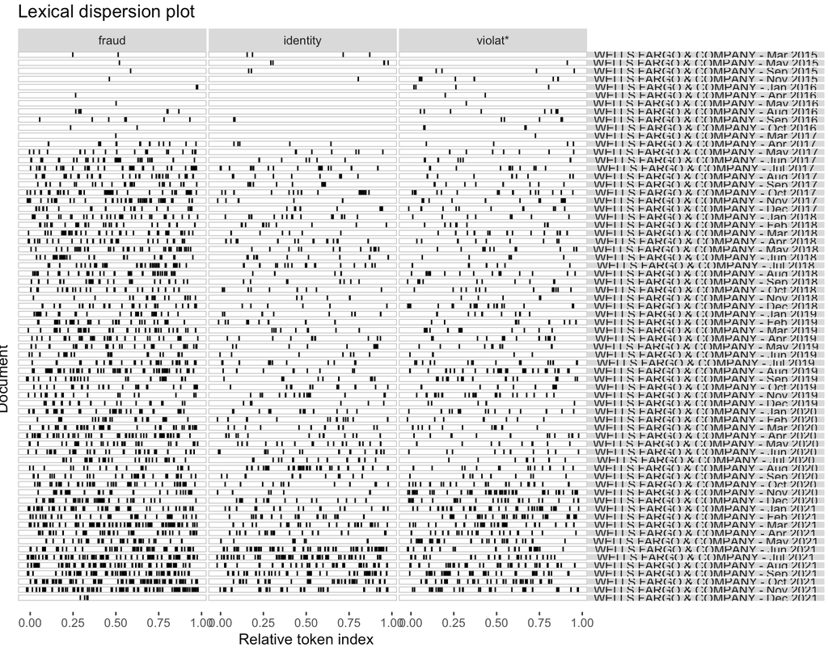

```r
knitr::include_graphics("images/lexical_dispersion.png")
```

## 4. Deriving Variables

Here’s the key part. We want to calculate the similarity of each Company-Year’s worth of complaints to one another. E.g. We compare Wells Fargo complaints from 2021 to Wells Fargo complaints from 2020 using a similarity score for each year.

```r
# Calculate cosine similarity
tstat_simil <- textstat_simil(dfmat_complaints, method = "cosine")

# Convert to tibble
tstat_simil_df <- as_tibble(tstat_simil)

# Add descriptive tags
tstat_simil_df <- tstat_simil_df %>%
    mutate(
        year1=as.numeric(str_sub(document1,-4,-1)),
        year2=as.numeric(str_sub(document2,-4,-1)),
        company1=sub(" .*", "", document1),
        company2=sub(" .*", "", document2)
    )
```

And here’s a visualisation of the similarity score (i.e. derived variable). A score of 1 means that the nature of this year’s versus the previous year’s complaints is identical. The closer to zero, the more different is one Company-Year to another.

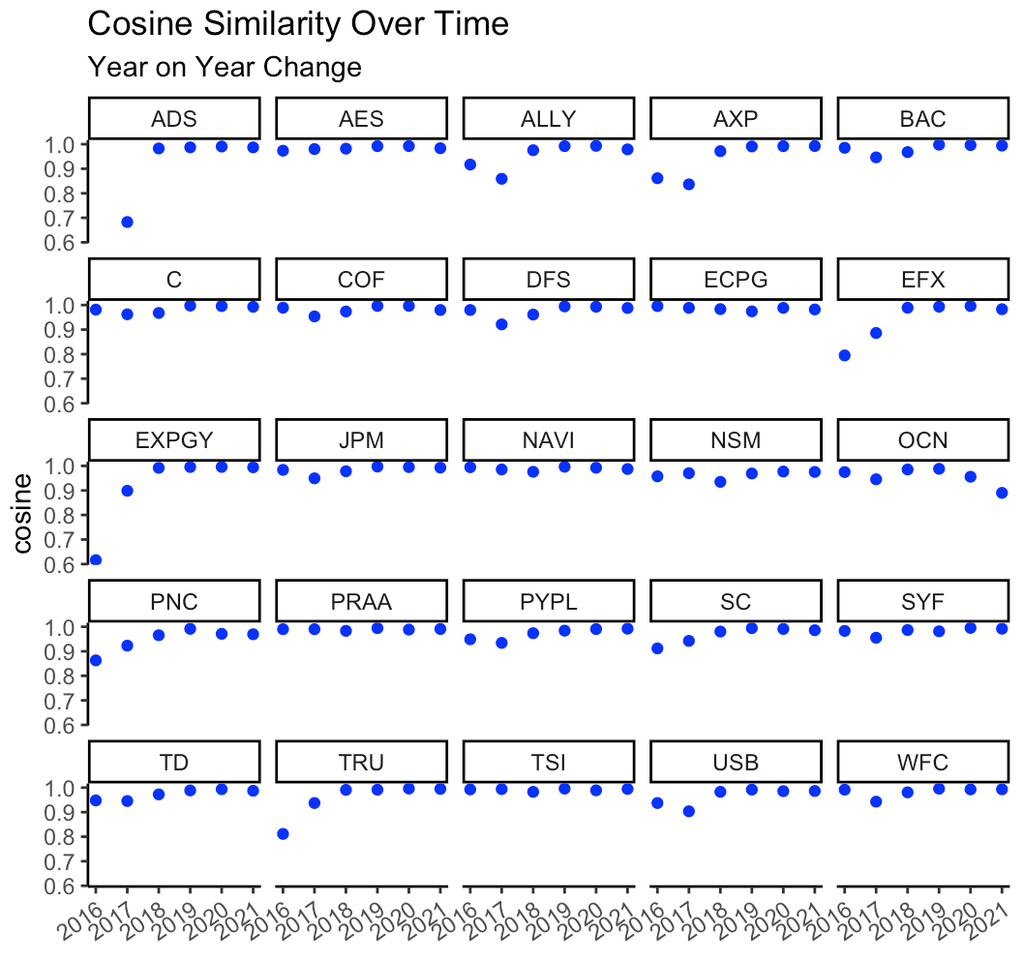

```r
# Plot graph
tstat_simil_df %>%
    filter(year1==(year2-1),company1==company2) %>%
    group_by(year1,year2) %>%
        ggplot(aes(x=year2,y=cosine)) +
            geom_point(col="blue") + theme_classic() +
            facet_wrap(~company1) +
            theme(axis.text.x = element_text(angle = 35, hjust=1)) +
            labs(title="Cosine Similarity Over Time",subtitle="Year on Year Change",x="")
```

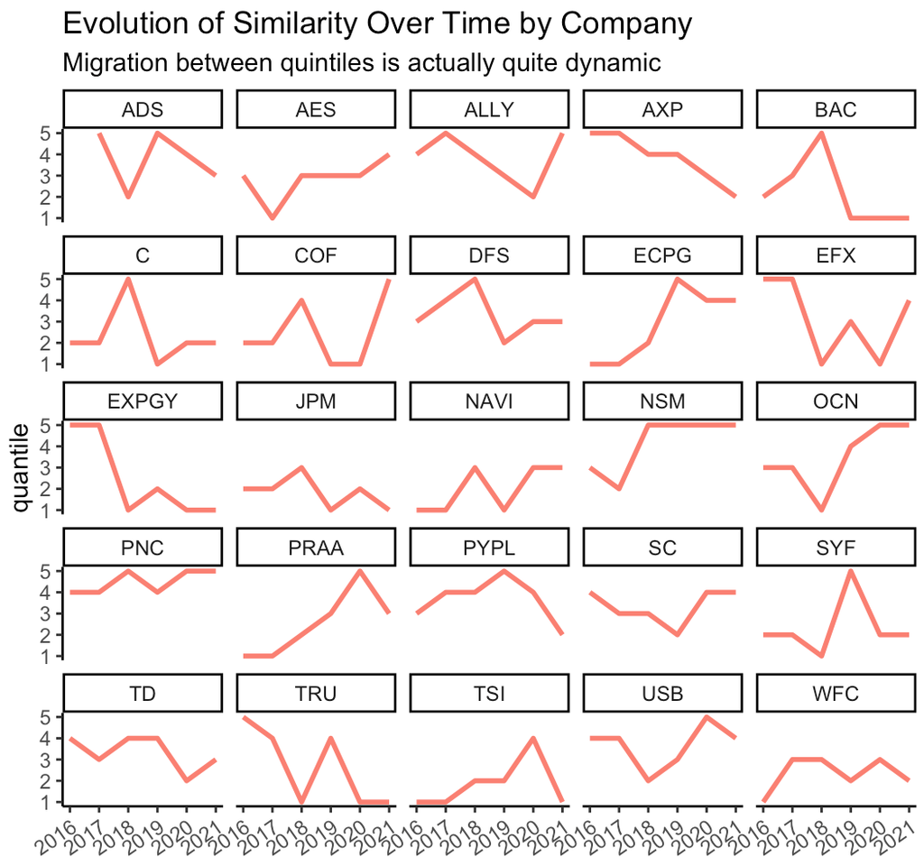

```r
#Plot graph
tstat_simil_df %>%
    filter(year1==(year2-1),company1==company2) %>%
    group_by(year1,year2) %>%
    mutate(
        rank = dense_rank(desc(cosine)),
        quantile = ntile(desc(cosine),5),
        date=make_date(year1+2,1,1)) %>%
        ggplot(aes(x=year2,y=quantile)) +
            geom_line(col="salmon",size=1) + theme_classic() +
            facet_wrap(~company1) +
            theme(axis.text.x = element_text(angle = 35, hjust=1)) +
            labs(title="Evolution of Similarity Over Time by Company",subtitle="Migration between quintiles is actually quite dynamic",x="")
```

## 5. Rank Ordering & Quintile Segmentation

To prepare the similarity score for testing against the Fama-French (FF) factor model, we need to:

- Rank companies by their similarity score by year
- Assign these to quintiles
- Create portfolio weights for processing later in the Fama-French regression model

```r
# Calculate and assign stocks to quantiles by similarity score
simil_var2 <- tstat_simil_df %>%
    filter(year1==(year2-1),company1==company2) %>%
    group_by(year1,year2) %>%
    mutate(
        rank = dense_rank(desc(cosine)),
        quantile = ntile(desc(cosine),5),
        date=make_date(year1+2,1,1)
        )

# Convert dataframes to xts for processing in portfolio weights
interim <- simil_var2 %>%
    ungroup() %>%
    select(date,company1,quantile) %>%
    filter(date<=as.Date("2021-12-31"))

# Wrangle for quintile 1
q1 <- interim %>% filter(quantile==1) %>% group_by(date) %>% mutate(quantile = quantile/sum(quantile)) %>% spread(company1,quantile) %>% replace(is.na(.), 0)
q1_xts <- xts(as.data.frame(q1)[,-1], order.by=as.data.frame(q1)[,1])

# Wrangle for quintile 2
q2 <- interim %>% filter(quantile==2) %>% group_by(date) %>% mutate(quantile = quantile/sum(quantile)) %>% spread(company1,quantile) %>% replace(is.na(.), 0)
q2_xts <- xts(as.data.frame(q2)[,-1], order.by=as.data.frame(q2)[,1])

# Wrangle for quintile 3
q3 <- interim %>% filter(quantile==3) %>% group_by(date) %>% mutate(quantile = quantile/sum(quantile)) %>% spread(company1,quantile) %>% replace(is.na(.), 0)
q3_xts <- xts(as.data.frame(q3)[,-1], order.by=as.data.frame(q3)[,1])

# Wrangle for quintile 4
q4 <- interim %>% filter(quantile==4) %>% group_by(date) %>% mutate(quantile = quantile/sum(quantile)) %>% spread(company1,quantile) %>% replace(is.na(.), 0)
q4_xts <- xts(as.data.frame(q4)[,-1], order.by=as.data.frame(q4)[,1])

# Wrangle for quintile 5
q5 <- interim %>% filter(quantile==5) %>% group_by(date) %>% mutate(quantile = quantile/sum(quantile)) %>% spread(company1,quantile) %>% replace(is.na(.), 0)
q5_xts <- xts(as.data.frame(q5)[,-1], order.by=as.data.frame(q5)[,1])
```

Here’s a visualisation of the weights. Since we have 25 stocks in our universe, a quintile will be 5 stocks. Within each quintile, each stock will take a 20% weighting.

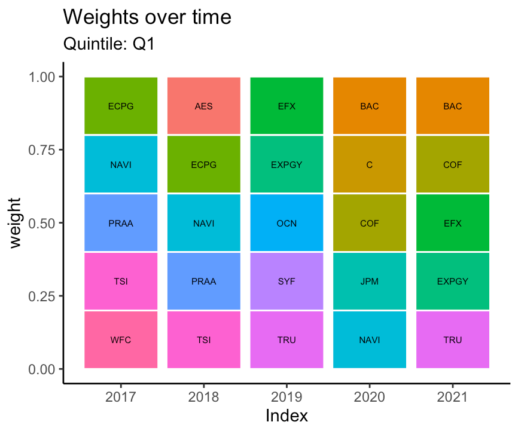

```r
knitr::include_graphics("images/q1_weights.png")
```

And here we calculate the weights for a Q5-Q1 portfolio.

```r
# Construct 130/30 stock portfolio
q5_q1 <- q1 %>%
    gather(symbol,weight,-date) %>%
    filter(weight!=0) %>%
    mutate(weight=weight*-1*1/3) %>%
    rbind(q5 %>% gather(symbol,weight,-date) %>% filter(weight!=0) %>% mutate(weight=weight*1.33)) %>%
    group_by(date) %>%
    spread(symbol,weight) %>%
    replace(is.na(.), 0)
q5_q1_xts <- xts(as.data.frame(q5_q1)[,-1], order.by=as.data.frame(q5_q1)[,1])
```

And here’s a visualisation of the Q5-Q1 portfolio weight. TBH, not quite sure what’s the best practice for calculating this differential so we went with a long-short portfolio. Long the stocks from the favoured quintile and short the stocks from the disfavoured quintile. The favoured quintile was then weighted at 130 and the disfavoured at 30 to give a 130/30 allocation. Notice that the long stocks sum to above 1.00 and the short stocks have negative weights and sum to -1/3.

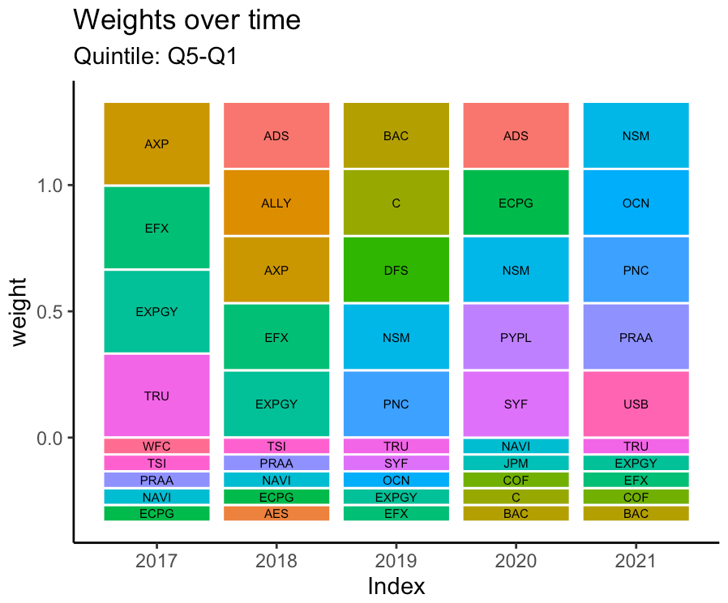

```r
knitr::include_graphics("images/q5_q1_weights.png")
```

## 6. Alpha Calculation Against Fama-French Factor Model

The code for this section is available in `portfolio2.R` and can be largely run as is. We’ll skip it in this document for sake of brevity. Go to `Line 62` to adjust which quantile you want the calculation to run. `q1_xts` for Q1, `q5_xts` for Q5, `q5_q1_xts` for Q5-Q1.

Here are the resulting portfolios for each quintile. Inspecting the differences visually, it’s clear to verify that Portfolio Q1 performed worst and Q5 second best. The 130/30 long-short portfolio is best.

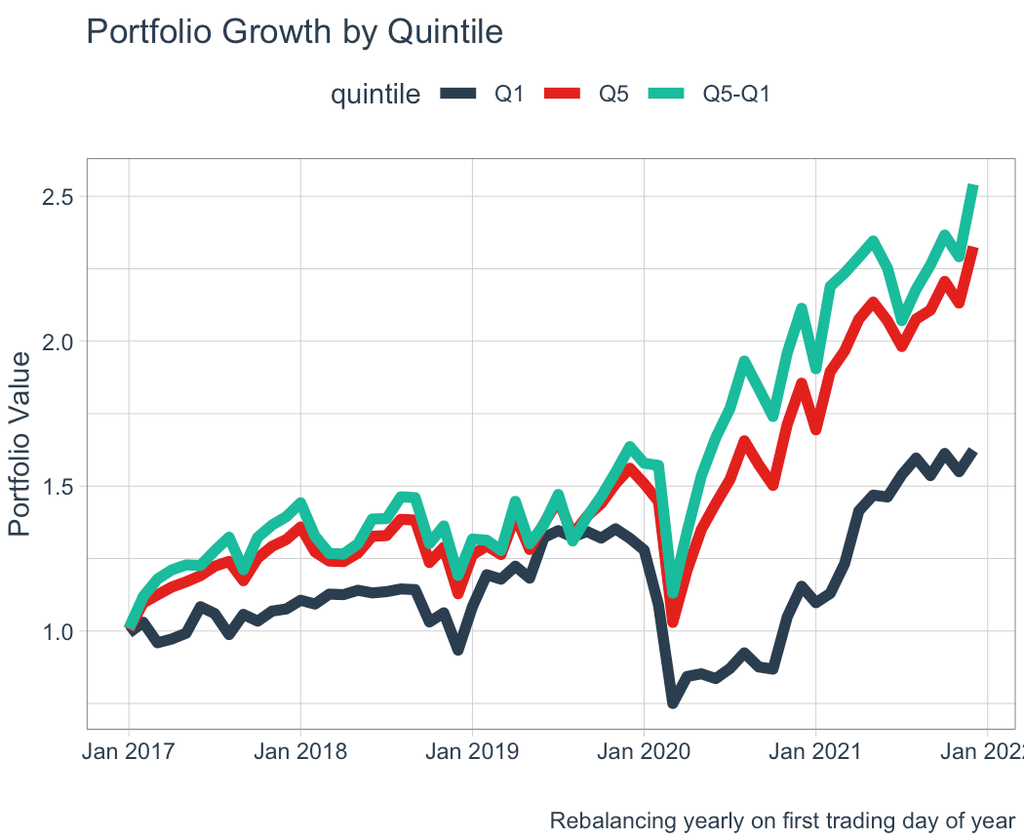

```r
knitr::include_graphics("images/portfolio_comp.png")
```

We now report the performance of the various portfolios against the Fama-French three factor model.

```r
# Print table
library(readxl)
dt <- read_xlsx("data/regression_results2.xlsx")
opts <- options(knitr.kable.NA = "")
knitr::kable(dt,caption="Fama-French Three Factor Model Regression Results",digits = 4,escape=TRUE)
```

Fama-French Three Factor Model Regression Results

| Quintile | Coefficients | Estimate | Std. Error | t-value | Pr(>\|t\|) | Significance | R-squared |
| --- | --- | --- | --- | --- | --- | --- | --- |
| Q1 | (Intercept) | -0.0043 | 0.0055 | -0.788 | 0.4340 |  | 0.7495 |
| Q1 | Mkt.RF | 1.2782 | 0.1148 | 11.131 | 0.0000 | *** | 0.7495 |
| Q1 | SMB | 0.1522 | 0.2014 | 0.756 | 0.4530 |  | 0.7495 |
| Q1 | HML | 0.5072 | 0.1445 | 3.509 | 0.0009 | *** | 0.7495 |
| Q5 | (Intercept) | -0.0002 | 0.0050 | -0.044 | 0.9648 |  | 0.7662 |
| Q5 | Mkt.RF | 1.2892 | 0.1054 | 12.235 | 0.0000 | *** | 0.7662 |
| Q5 | SMB | 0.0071 | 0.1848 | 0.039 | 0.9693 |  | 0.7662 |
| Q5 | HML | 0.3905 | 0.1326 | 2.944 | 0.0047 | ** | 0.7662 |
| Q5-Q1 | (Intercept) | 0.0016 | 0.0069 | 0.234 | 0.8158 |  | 0.6224 |
| Q5-Q1 | Mkt.RF | 1.2783 | 0.1458 | 8.767 | 0.0000 | *** | 0.6224 |
| Q5-Q1 | SMB | -0.0134 | 0.2557 | -0.053 | 0.9583 |  | 0.6224 |
| Q5-Q1 | HML | 0.3874 | 0.1835 | 2.111 | 0.0394 | * | 0.6224 |

Unfortunately the alpha term isn’t significant in any model. However, even though not statistically significant, there is a gradation of results in the sense that $\alpha$`Q1` < $\alpha$`Q5` < $\alpha$`Q5-Q1`, which is what we’d expect to see when running such an exercise.

## 7. Concluding Remarks

Overall, this is a good first pass. Some ideas on what to do next to perhaps reach a significant alpha term on the Fama-French model:

- **Increase periodicity.** Instead of a fixed Jan - Dec yearly comparison with annual rebalancing, do a 12 month rolling window with quarterly rebalancing.
- **Expand stock universe.** Check whether increasing number of ticker-tied company names is viable given the dataset.
- **Survivorship bias.** One of the top 25 stocks (Ditech Financial LLC) wasn’t included in the portfolio calculations since it delisted due to bankruptcy and Yahoo removed the price series data. Finding an alternative price history source and adding it into the calculations may improve significance.
- **Alternative derived variables.** Construct variations of the similarity score. One idea is to add semantic analysis. One could use the Loughran-McDonald financial dictionary and run cosine similarity over this subset instead of the whole corpus.

## 8. About the Author

Witold is currently looking for opportunities at alternative data companies with ties to the investment world or at systematically-inclined hedge funds.

- [LinkedIn profile](https://www.linkedin.com/in/kozlowskiwitold/)
- [Current CV](https://www.dropbox.com/s/k41oh1gz83jy189/WKozlowski_CV.pdf?dl=0)
- [China Charts](https://www.realchinacharts.com/), a weekly newsletter he co-authors with a colleague